# Homework #1: Supervised Learning

Due: Tue Feb 08 | 10:30 am

**SYS 6018 | Sp 2022 | University of Virginia**

# Required R packages and Directories

```r
data.dir = 'https://mdporter.github.io/SYS6018/data/' # data directory
library(R6018)     # functions for SYS-6018
library(tidyverse) # functions for data manipulation
```

# Problem 1: Evaluating a Regression Model

## a. Create a set of functions to generate data from the following distributions:

$$\begin{align*}
X &\sim \mathcal{N}(0, 1) \\
Y &= -1 + .5X + .2X^2 + \epsilon \\
\epsilon &\sim \mathcal{N}(0,\, \sigma)
\end{align*}$$

```r
library(dplyr)
#functions for three values
datagenX <- function(n, sigma){
  X <- rnorm(n, 0, 1)

}
f <- function(x){
  -1 + 0.5*x + 0.2*x^2
}
datagenY <- function(n, sigma, X){
  f(X) + rnorm(n, 0, sigma)
}
```

## b. Simulate $n=100$ realizations from these distributions using $\sigma=3$. Produce a scatterplot and draw the true regression line $f(x) = E[Y \mid X=x]$.

- Use `set.seed(611)` prior to generating the data.

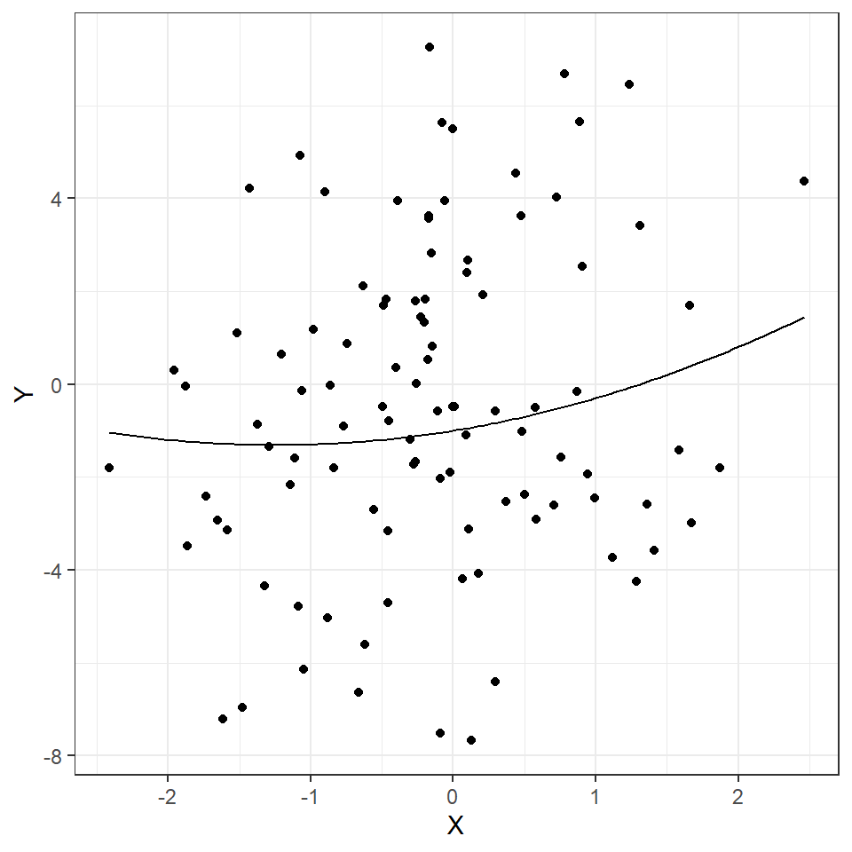

```r
set.seed(611)
# create data
X = datagenX(100, 3)
Y = datagenY(100, 3, X)
data = tibble(X = X,
  Y = Y)
plot = data %>%
  ggplot(aes(x=X, y=Y)) + geom_point() + geom_function(fun = f, color = 'black')
plot
```

## c. Fit three polynomial regression models using least squares: linear, quadratic, and cubic. Produce another scatterplot, add the fitted lines and true population line $f(x)$ using different colors, and add a legend that maps the line color to a model.

- Note: The true model is quadratic, but we are also fitting linear (less complex) and cubic (more complex) models.

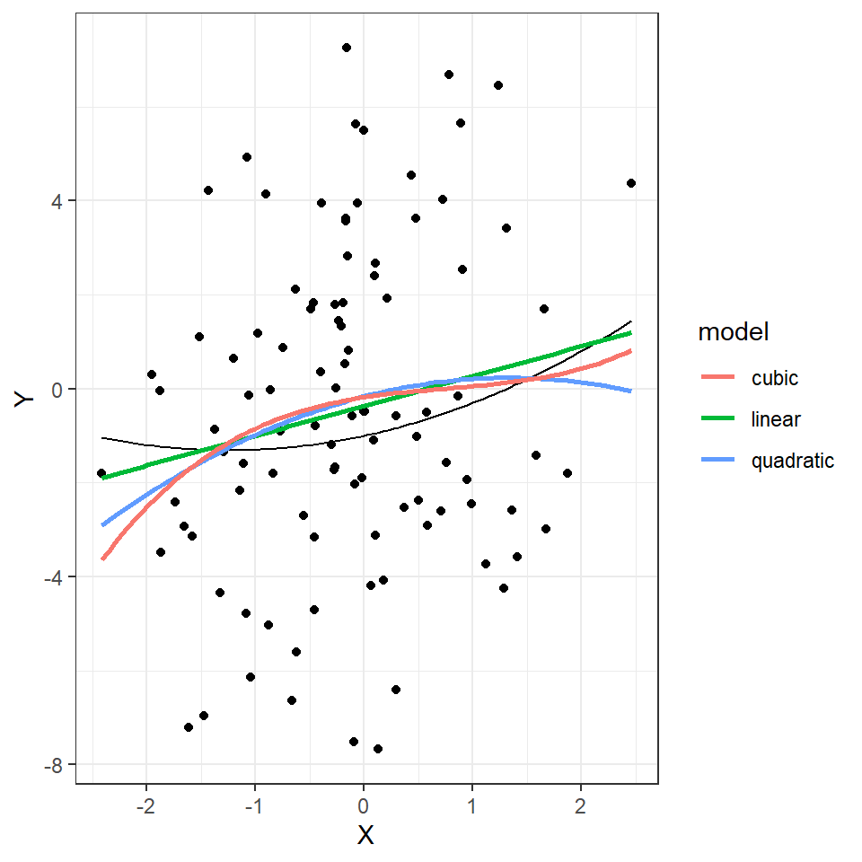

```r
#linear, quadratic, and cubic regression models
linear_model = lm(Y ~ X, data = data)
quadratic_model = lm(Y ~ poly(X, 2), data = data)
cubic_model = lm(Y ~ poly(X, 3), data= data)


#predictions
preds1 = predict(linear_model, data = X)
preds2 = predict(quadratic_model, data = X)
preds3 = predict(cubic_model, data = X)

poly.data = tibble(x = X, linear=preds1, quadratic=preds2, cubic=preds3) %>%  # long data
  pivot_longer(-x, names_to="model", values_to="Y")

plot +
  geom_smooth(method="lm", se=FALSE, aes(color="linear")) +
  geom_smooth(method="lm", formula="Y~poly(x,2)", se=FALSE, aes(color="quadratic")) +
  geom_smooth(method="lm", formula="Y~poly(x,3)", se=FALSE, aes(color="cubic")) +
  scale_color_discrete(name="model")
```

## d. Simulate a *test data* set of 10,000 observations from the same distributions. Use `set.seed(612)` prior to generating the test data.

- Calculate the estimated mean squared error (MSE) for each model.
- Are the results as expected?

```r
set.seed(612)
# create data
X_m = datagenX(10000, 3)
Y_m = datagenY(10000, 3, X_m)
preds4 = predict(linear_model, data = X_m)
preds5 = predict(quadratic_model, data = X_m)
preds6 = predict(cubic_model, data = X_m)
mse1 = mean((Y_m - preds4)^2)
mse2 = mean((Y_m - preds5)^2)
mse3 = mean((Y_m - preds6)^2)
#The result is unexpected. Because our model is quadratic, but the least MES is under linear model.
```

[output not shown]

## f. The MSE scores obtained in part *d* came from one realization of training data. Here will we explore how much variation there is in the MSE scores by replicating the simulation many times.

- Re-run parts b. and c. (i.e., generate training data and fit models) 100 times.
- Calculate the MSE for all simulations.
- Create kernel density or histogram plots of the resulting MSE values for each model.
- Use `set.seed(613)` prior to running the simulation and do not set the seed in any other places.
- Use the same test data from part d. (This question is only about the variability that comes from the training data).

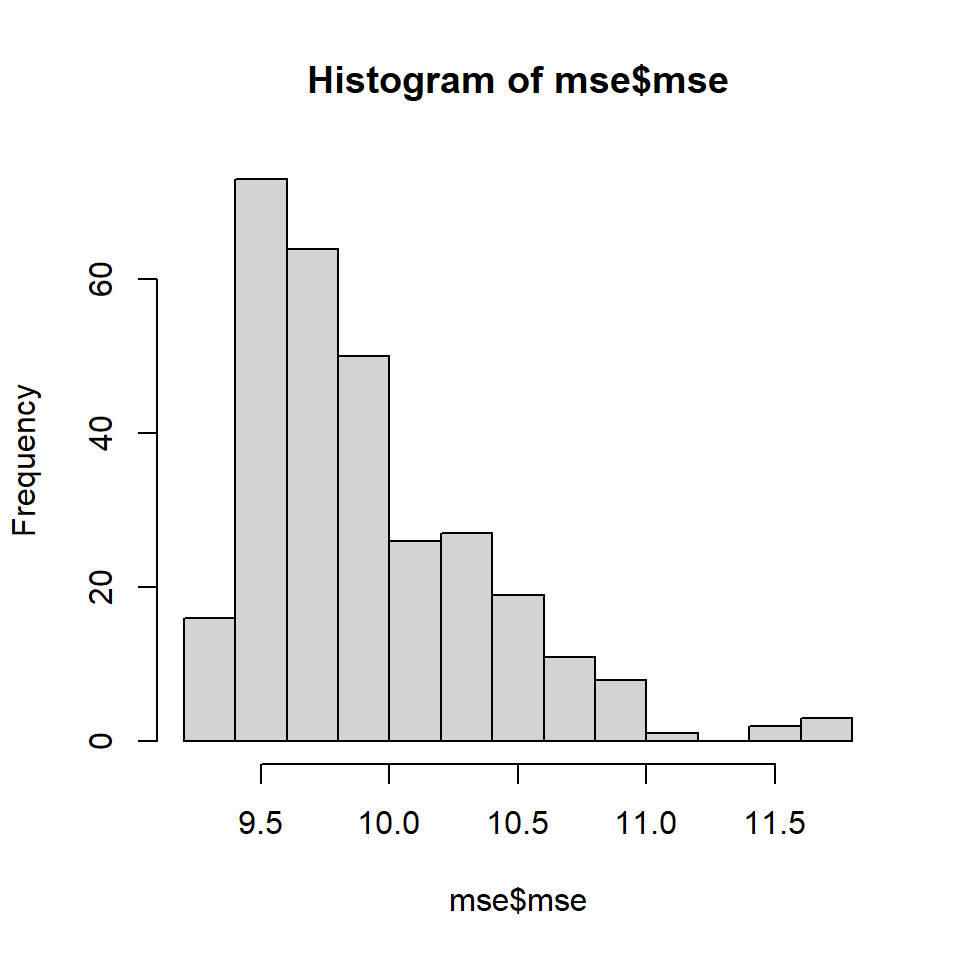

```r
set.seed(613)
mse = tibble()
linear_count = 0
quadratic_count = 0
cubic_count = 0
for (index in 1:100){
  X = datagenX(100, 3)
  Y = datagenY(100, 3, X)
  data = tibble(X = X,
    Y = Y)

  #linear, quadratic, and cubic regression models
  linear_model = lm(Y ~ X, data = data)
  quadratic_model = lm(Y ~ poly(X, 2), data = data)
  cubic_model = lm(Y ~ poly(X, 3), data= data)

  #predictions
  predsa = predict(linear_model, data = X_m)
  predsb = predict(quadratic_model, data = X_m)
  predsc = predict(cubic_model, data = X_m)

  msea = mean((Y_m - predsa)^2)
  mseb = mean((Y_m - predsb)^2)
  msec = mean((Y_m - predsc)^2)
  if(min(c(msea,mseb,msec)) == msea){
    linear_count = linear_count + 1
  }else if(min(c(msea,mseb,msec)) == mseb){
    quadratic_count = quadratic_count + 1
  }else{
    cubic_count = cubic_count + 1
  }
  mse = bind_rows(mse, tibble(mse=c(msea,mseb,msec)))
}
hist(mse$mse)
```

## g. Show a count of how many times each model was the best. That is, out of the 100 simulations, count how many times each model had the lowest MSE.

```r
tibble(type = c("linear", " quadratic", "cubic"),counts = c(linear_count, quadratic_count, cubic_count))
```

| type | counts |
| --- | --- |
| linear | 97 |
| quadratic | 2 |
| cubic | 1 |

## h. Repeat the simulation in part *f*, but use $\sigma=2$. Report the number of times each model was best (you do not need to produce any plots). Use the same `set.seed(613)` prior to running the simulation and do not set the seed in any other places.

```r
set.seed(613)
linear_count = 0
quadratic_count = 0
cubic_count = 0
mse = tibble()
for (index in 1:100){
  X = datagenX(100, 2)
  Y = datagenY(100, 2, X)
  data = tibble(X = X,
    Y = Y)

  #linear, quadratic, and cubic regression models
  linear_model = lm(Y ~ X, data = data)
  quadratic_model = lm(Y ~ poly(X, 2), data = data)
  cubic_model = lm(Y ~ poly(X, 3), data= data)

  #predictions
  predsa = predict(linear_model, data = X_m)
  predsb = predict(quadratic_model, data = X_m)
  predsc = predict(cubic_model, data = X_m)

  msea = mean((Y_m - predsa)^2)
  mseb = mean((Y_m - predsb)^2)
  msec = mean((Y_m - predsc)^2)
  if(min(c(msea,mseb,msec)) == msea){
    linear_count = linear_count + 1
  }else if(min(c(msea,mseb,msec)) == mseb){
    quadratic_count = quadratic_count + 1
  }else{
    cubic_count = cubic_count + 1
  }
  mse = bind_rows(mse, tibble(mse=c(msea,mseb,msec)))
}
tibble(type = c("linear", " quadratic", "cubic"),counts = c(linear_count, quadratic_count, cubic_count))
```

| type | counts |
| --- | --- |
| linear | 98 |
| quadratic | 2 |
| cubic | 0 |

## i. Repeat *h*, but now use $\sigma=4$ and $n=300$.

```r
set.seed(613)
linear_count = 0
quadratic_count = 0
cubic_count = 0
mse = tibble()
for (index in 1:100){
  X = datagenX(300, 4)
  Y = datagenY(300, 4, X)
  data = tibble(X = X,
    Y = Y)

  #linear, quadratic, and cubic regression models
  linear_model = lm(Y ~ X, data = data)
  quadratic_model = lm(Y ~ poly(X, 2), data = data)
  cubic_model = lm(Y ~ poly(X, 3), data= data)

  #predictions
  predsa = predict(linear_model, data = X_m)
  predsb = predict(quadratic_model, data = X_m)
  predsc = predict(cubic_model, data = X_m)

  msea = mean((Y_m - predsa)^2)
  mseb = mean((Y_m - predsb)^2)
  msec = mean((Y_m - predsc)^2)
  if(min(c(msea,mseb,msec)) == msea){
    linear_count = linear_count + 1
  }else if(min(c(msea,mseb,msec)) == mseb){
    quadratic_count = quadratic_count + 1
  }else{
    cubic_count = cubic_count + 1
  }
  mse = bind_rows(mse, tibble(mse=c(msea,mseb,msec)))
}
tibble(type = c("linear", " quadratic", "cubic"),counts = c(linear_count, quadratic_count, cubic_count))
```

| type | counts |
| --- | --- |
| linear | 98 |
| quadratic | 2 |
| cubic | 0 |